# GrowthAnalysis_Basia

Sophie Buysse

2026-01-06

## Set up

The goal of this code is to read in Basia’s leaf number and rosette area data collected on Native lines of *Arabidopsis thaliana* in current and future SW chamber common gardens from Nov 2024 - Feb 2025. All leaf counts were done on live plants. All rosette area was collected from imageJ outlines of top down rosette photos. Contact Sophie Buysse if you would like access to the raw photos - they are not included in the github repository.

```r
library(dplyr) # for manipulating data formats and cleaning data
```

```r
library(tidyr) # same as above
library(ggplot2) # for making plots
library(ggpubr) # for making plots
library(emmeans) # for statistics
#library(lme4) # for mixed modelling - not needed
#library(lmerTest) # for p value from mixed model - not needed

# prep for doing statistical analyses
options(contrasts = c("contr.sum", "contr.poly"))

# set seed
set.seed(422)
```

## Read in Data

Note: we initially split our leaf number counts into a total leaf number of all leaves we could see including tiny leaves that appear under the main rosette and come out at odd angles and only the leaves on the main rosette. The results of both leaf number counts are similar so the publication only focuses on the main rosette leaves though analyses for both are shown throughout this code.

```r
LeafNum <- read.csv("../data/RosetteLeafNumber_04242025_SB.csv")
RosArea <- read.csv("../data/RosetteArea_04242025_SB.csv")
TotalNum <- read.csv("../data/TotalLeafNumber_04242025_SB.csv")
Emergence<- read.csv("../data/EmergenceDates.csv")
```

## Format Data

Organize data frames, remove columns that we don’t need, make character values in columns to NA, make number columns numeric

```r
# add genotype and population columns
LeafNum$Geno <- substr(LeafNum$PotLabel, 1, 3)
LeafNum$Population <- "IT"
LeafNum[LeafNum$Geno > 899 , "Population"] <- "SW"
# Ros genotype and population columns
RosArea$Geno <- substr(RosArea$PotLabe, 1,3)
RosArea$Population <-"IT"
RosArea[RosArea$Geno > 899, "Population"] <- "SW"
# TotalNum genotype and population columns
TotalNum$Geno <- substr(TotalNum$PotLabel, 1, 3)
TotalNum$Population <- "IT"
TotalNum[TotalNum$Geno > 899 , "Population"] <- "SW"


# remove not needed columns
LeafNum$Notes1 <- NULL #way one
LeafNum$Notes2 <- NULL
LeafNum$Notes3 <- NULL
LeafNum$Notes4 <- NULL
LeafNum$Notes5 <- NULL
LeafNum$Notes6 <- NULL
LeafNum$X12.23.2024 <- NULL
LeafNum$X12.27.2024 <- NULL
LeafNum$X2.14.2025 <- NULL
LeafNum$X2.17.2025 <- NULL
LeafNum$X2.21.2025 <- NULL
LeafNum$X2.24.2025 <- NULL
LeafNum$X2.28.2025 <- NULL
LeafNum$X1.20.2025 <- NULL
LeafNum$X2.10.2025
```

```
##  [1] "Removed" "Removed" "54"      "Removed" "51"      "Removed" "Removed"
##  [8] "Removed" "Removed" "Removed" "Removed" "Removed" "Removed" "Dead"
## [15] "Removed" "Removed" "Removed" "Dead"    "Removed" "Removed" "Dead"
## [22] "Dead"    "Removed" "53"      "Removed" "Dead"    "Removed" "Removed"
## [29] "Removed" "61"      "Removed" "Removed" "Removed" "Removed" "62"
## [36] "Removed" "Removed" "59"      "Removed" "Removed" "Removed" "Dead"
## [43] "Removed" "Removed" "Removed" "Removed" "Removed" "53"
```

```r
LeafNum$`2/10/2025`<- NULL

#Remove not needed columns of RosArea
RosArea$Notes6 <- NULL
RosArea$X2.24.2025 <- NULL
RosArea$X2.28.2025 <- NULL

# total leaf number
TotalNum$X12.23.2024 <- NULL
TotalNum$X12.27.2024 <- NULL
TotalNum$X2.14.2025 <- NULL
TotalNum$X2.17.2025 <- NULL
TotalNum$X2.21.2025 <- NULL
TotalNum$X2.24.2025 <- NULL
TotalNum$X2.28.2025 <-NULL
TotalNum$Notes5 <- NULL
TotalNum$Notes6 <- NULL



# get rid of the rows where the plant never emerged (NA, 0, or dead the whole time)
LeafNum <- LeafNum[!(LeafNum$PotLabel %in% c("114-3-C", "107-3-C","105-3-C","102-3-C", "107-3-F","114-3-F")), ]
#rid of rows for RosArea
RosArea <- RosArea[!(RosArea$PotLabel %in% c("114-3-C","107-3-C", "105-3-C", "102-3-C", "107-3-F", "114-3-F", "","", "Scale 61.0737", "Do the Monday photos first!", "Then the Friday photos")),]
# change "removed" and "dead" to NA instead so can treat as integers
LeafNum[LeafNum$X2.10.2025 == "Removed", "X2.10.2025"] <- NA
LeafNum[LeafNum$X2.7.2025 == "Removed", "X2.7.2025"] <- NA
LeafNum[LeafNum$X2.3.2025 %in% c("Removed", "removed"), "X2.3.2025"] <- NA
LeafNum[LeafNum$X1.31.2025 %in% c("Removed ", "Removed"), "X1.31.2025"] <- NA
LeafNum[LeafNum$X1.27.2025 == "Removed", "X1.27.2025"] <- NA
LeafNum[LeafNum$X1.24.2025 == "Removed", "X1.24.2025"] <- NA
LeafNum[LeafNum$X1.20.2024 == "Removed", "X1.20.2024"] <- NA

# add RosArea other columns here
RosArea[RosArea$X12.6.2024 == "Wrong Plant", "X12.6.2024"] <- NA
RosArea[RosArea$X12.11.2024 == "wrong plant", "X12.11.2024"] <- NA
RosArea[RosArea$X1.24.2025 == "?", "X1.24.2025"] <- NA

#Change remove from totalNum
TotalNum <- TotalNum[!(TotalNum$PotLabel %in% c("114-3-C", "107-3-C","105-3-C","102-3-C", "107-3-F","114-3-F")), ]
TotalNum[TotalNum$X2.10.2025 == "Removed", "X2.10.2025"] <- NA
TotalNum[TotalNum$X2.7.2025 == "Removed", "X2.7.2025"] <- NA
TotalNum[TotalNum$X2.3.2025 == "Removed", "X2.3.2025"] <- NA
TotalNum[TotalNum$X1.31.2025 %in% c("Removed", "Removed "), "X1.31.2025"] <- NA
TotalNum[TotalNum$X1.27.2025 == "Removed", "X1.27.2025"] <- NA
TotalNum[TotalNum$X1.24.2025 == "Removed", "X1.24.2025"] <- NA
TotalNum[TotalNum$X1.20.2024 %in% c("Removed","Removed "), "X1.20.2024"] <- NA
# rename a column
LeafNum <- rename(LeafNum, X1.20.2025 = X1.20.2024)
TotalNum <- rename(TotalNum, X1.20.2025 = X1.20.2024)
RosArea <-  rename(RosArea, X1.15.2025 = X1.15.2024)
# make population and trt columns factors and other things integers
LeafNum <- LeafNum %>%
  mutate(

    # add other columns here
    X2.7.2025 = as.integer(X2.7.2025),
    X2.3.2025 = as.integer(X2.3.2025),
    X1.31.2025 = as.integer(X1.31.2025),
    X1.27.2025 = as.integer(X1.27.2025),
    X1.24.2025 = as.integer(X1.24.2025),
    X1.20.2025 = as.integer(X1.20.2025),
    X1.17.2025 = as.integer(X1.17.2025),
    X1.13.2025 = as.integer(X1.13.2025),
    X1.10.2025 = as.integer(X1.10.2025),
    X1.6.2025 = as.integer(X1.6.2025),
    X1.3.2025 = as.integer(X1.3.2025),
    X12.30.2024 = as.integer(X12.30.2024),
    X2.10.2025 = as.integer(X2.10.2025),
    Population = as.factor(Population),
    Trt = as.factor(Trt),

  )
  RosArea <- RosArea %>%
    mutate(
      X11.25.2024 = as.numeric(X11.25.2024),
      X11.27.2024 = as.numeric(X11.27.2024),
      X11.29.2024 = as.numeric(X11.29.2024),
      X12.2.2024 = as.numeric(X12.2.2024),
      X12.4.2024 = as.numeric(X12.4.2024),
      X12.6.2024 = as.numeric(X12.6.2024),
      X12.9.2024 = as.numeric(X12.9.2024),
      X12.11.2024 = as.numeric(X12.11.2024),
      X12.13.2024 = as.numeric(X12.13.2024),
      X12.16.2024 = as.numeric(X12.16.2024),
      X12.18.2024 = as.numeric(X12.18.2024),
      X12.20.2024 = as.numeric(X12.20.2024),
      X12.23.2024 = as.numeric(X12.23.2024),
      X12.25.2024 = as.numeric(X12.25.2024),
      X12.27.2024 = as.numeric(X12.27.2024),
      X12.30.2024 = as.numeric(X12.30.2024),
      X1.1.2025 = as.numeric(X1.1.2025),
      X1.3.2025 = as.numeric(X1.3.2025),
      X1.6.2025 = as.numeric(X1.6.2025),
      X1.8.2025 = as.numeric(X1.8.2025),
      X1.10.2025 = as.numeric(X1.10.2025),
      X1.13.2025 = as.numeric(X1.13.2025),
      X1.15.2025 = as.numeric(X1.15.2025),
      X1.17.2025 = as.numeric(X1.17.2025),
      X1.20.2025 = as.numeric(X1.20.2025),
      X1.22.2025 = as.numeric(X1.22.2025),
      X1.24.2025 = as.numeric(X1.24.2025),
      X1.27.2025 = as.numeric(X1.27.2025),
      X1.29.2025 = as.numeric(X1.29.2025),
      X1.31.2025 = as.numeric(X1.31.2025),
      X2.3.2025 = as.numeric(X2.3.2025),
      X2.5.2025 = as.numeric(X2.5.2025),
      X2.7.2025 = as.numeric(X2.7.2025),
      X2.10.2025 = as.numeric(X2.10.2025),
      Population = as.factor(Population),
      Trt = as.factor(Trt)
    )
 #TotalNum into Factors
  TotalNum <- TotalNum %>%
  mutate(

    # add other columns here
    X2.7.2025 = as.integer(X2.7.2025),
    X2.3.2025 = as.integer(X2.3.2025),
    X1.31.2025 = as.integer(X1.31.2025),
    X1.27.2025 = as.integer(X1.27.2025),
    X1.24.2025 = as.integer(X1.24.2025),
    X1.20.2025 = as.integer(X1.20.2025),
    X1.17.2025 = as.integer(X1.17.2025),
    X1.13.2025 = as.integer(X1.13.2025),
    X1.10.2025 = as.integer(X1.10.2025),
    X1.6.2025 = as.integer(X1.6.2025),
    X1.3.2025 = as.integer(X1.3.2025),
    X12.30.2024 = as.integer(X12.30.2024),
    X2.10.2025 = as.integer(X2.10.2025),
    Population = as.factor(Population),
    Trt = as.factor(Trt),

  )
```

## Data Exploration

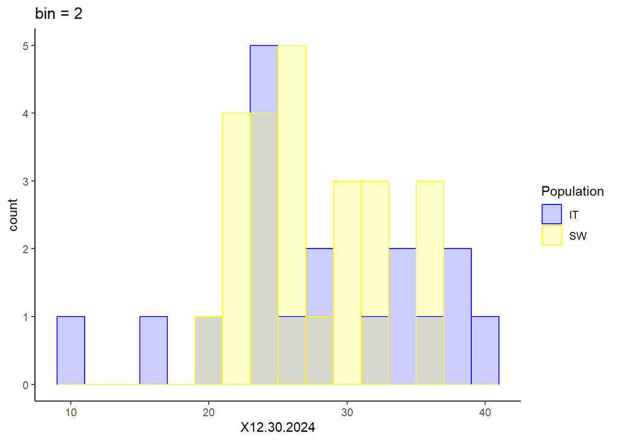

```r
# leafnum by population
ggplot(data = LeafNum, aes(X12.30.2024))+
  geom_histogram(aes( fill = Population, color = Population), binwidth = 2, position = 'identity', alpha = 0.2)+
  scale_fill_manual(values = c("blue", "yellow"))+
  scale_color_manual(values = c("blue", "yellow"))+
  labs(title = "bin = 2")+
  theme_classic()
```

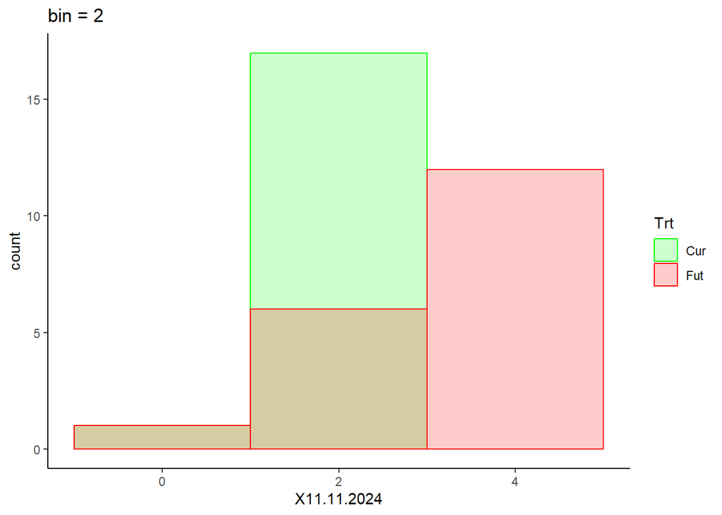

```r
# leafnum by treatment
ggplot(data = LeafNum, aes(X11.11.2024))+
  geom_histogram(aes( fill = Trt, color = Trt), binwidth = 2, position = 'identity', alpha = 0.2)+
  scale_fill_manual(values = c("green", "red"))+
  scale_color_manual(values = c("green", "red"))+
  labs(title = "bin = 2")+
  theme_classic()
```

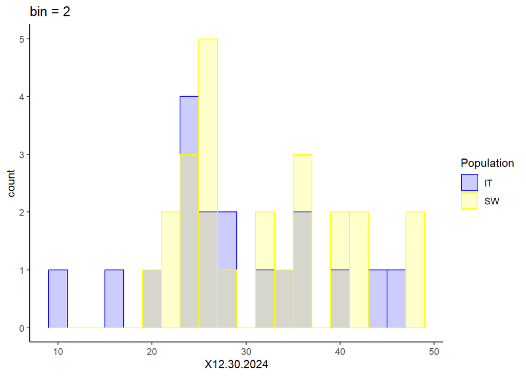

```r
#totalNum plot by population
ggplot(data = TotalNum, aes(X12.30.2024))+
  geom_histogram(aes( fill = Population, color = Population), binwidth = 2, position = 'identity', alpha = 0.2)+
  scale_fill_manual(values = c("blue", "yellow"))+
  scale_color_manual(values = c("blue", "yellow"))+
  labs(title = "bin = 2")+
  theme_classic()
```

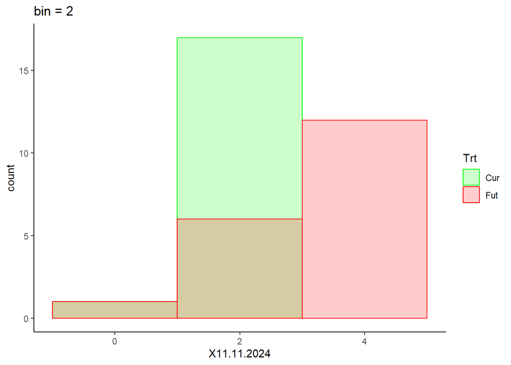

```r
# totalnum plot by treatment
ggplot(data = TotalNum, aes(X11.11.2024))+
  geom_histogram(aes( fill = Trt, color = Trt), binwidth = 2, position = 'identity', alpha = 0.2)+
  scale_fill_manual(values = c("green", "red"))+
  scale_color_manual(values = c("green", "red"))+
  labs(title = "bin = 2")+
  theme_classic()
```

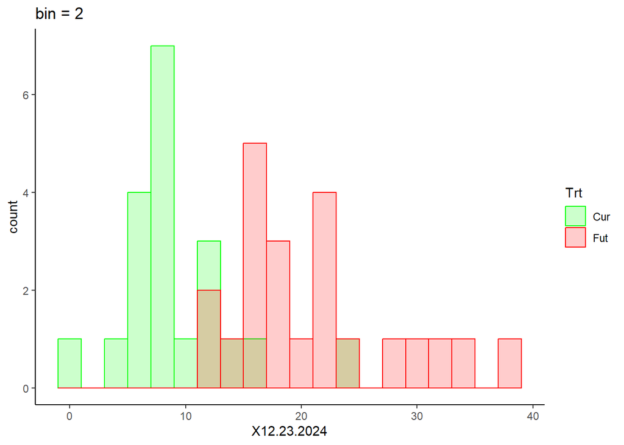

```r
#Ros Area by treatment
ggplot(data = RosArea, aes(X12.23.2024))+
  geom_histogram(aes( fill = Trt, color = Trt), binwidth = 2, position = 'identity', alpha = 0.2)+
  scale_fill_manual(values = c("green", "red"))+
  scale_color_manual(values = c("green", "red"))+
  labs(title = "bin = 2")+
  theme_classic()
```

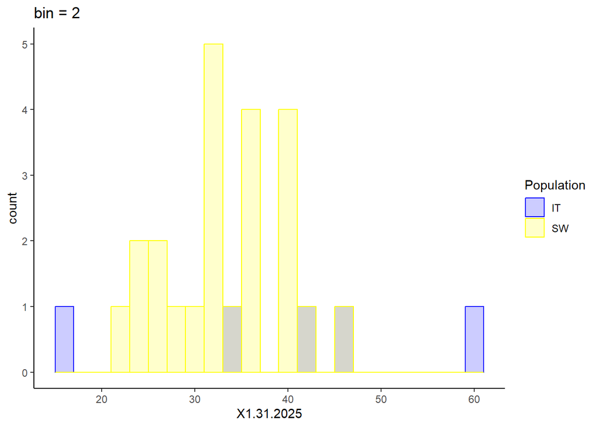

```r
# rosarea by population
ggplot(data = RosArea, aes(X1.31.2025))+
  geom_histogram(aes( fill = Population, color = Population), binwidth = 2, position = 'identity', alpha = 0.2)+
  scale_fill_manual(values = c("blue", "yellow"))+
  scale_color_manual(values = c("blue", "yellow"))+
  labs(title = "bin = 2")+
  theme_classic()
```

Pop 11.11.24, 11.25.24, 12.9.24, 12.30.24 good

We also want to make initial plots of the leaf number/rosette area over time so we can look for any irregularities.

```r
# merge in emergence date
LeafNum <- merge(LeafNum, Emergence[ , c("PotLabel", "EmergenceDate", "BoltingDate")], by = c("PotLabel"), all.x = TRUE)
TotalNum <- merge(TotalNum, Emergence[ , c("PotLabel", "EmergenceDate", "BoltingDate")], by = c("PotLabel"), all.x = TRUE)
RosArea <- merge(RosArea, Emergence[ , c("PotLabel", "EmergenceDate", "BoltingDate")], by = c("PotLabel"), all.x = TRUE)

# make long format
LeafNumTime <- pivot_longer(LeafNum, cols = !(c(Population, Trt, PotLabel, Flat, Geno, Pos, EmergenceDate, BoltingDate)), names_to = "Date", values_to = "LeafNum")

# convert that column do a date format
LeafNumTime$Date <- as.Date(sub("^X","", LeafNumTime$Date), format = "%m.%d.%Y")
LeafNumTime$EmergenceDate <- as.Date(LeafNumTime$EmergenceDate, format = "%m/%d/%Y")
LeafNumTime$BoltingDate <- as.Date(LeafNumTime$BoltingDate, format = "%m/%d/%Y")

LeafNumTime$Date2 <- julian(LeafNumTime$Date, origin = as.Date("2024-11-4"))
LeafNumTime$DaysFromEmergence <- as.numeric(LeafNumTime$Date - LeafNumTime$EmergenceDate)

#RosArea
RosAreaTime <- pivot_longer(RosArea, cols = !(c(Population, Trt, PotLabel, Flat, Geno, Pos, EmergenceDate, BoltingDate)), names_to = "Date", values_to = "LeafArea")

RosAreaTime$Date <- as.Date(sub("^X","", RosAreaTime$Date), format = "%m.%d.%Y")
RosAreaTime$EmergenceDate <- as.Date(RosAreaTime$EmergenceDate, format = "%m/%d/%Y")
RosAreaTime$BoltingDate <- as.Date(RosAreaTime$BoltingDate, format = "%m/%d/%Y")

RosAreaTime$Date2 <- julian(RosAreaTime$Date, origin = as.Date("2024-11-4"))
RosAreaTime$DaysFromEmergence <- as.numeric(RosAreaTime$Date - RosAreaTime$EmergenceDate)

#TotalNum
TotalNumTime <- pivot_longer(TotalNum, cols = !(c(Population, Trt, PotLabel, Flat, Geno, Pos, EmergenceDate, BoltingDate)), names_to = "Date", values_to = "TotalNum")

TotalNumTime$Date <- as.Date(sub("^X","", TotalNumTime$Date), format = "%m.%d.%Y")
TotalNumTime$EmergenceDate <- as.Date(TotalNumTime$EmergenceDate, format = "%m/%d/%Y")
TotalNumTime$BoltingDate <- as.Date(TotalNumTime$BoltingDate, format = "%m/%d/%Y")


TotalNumTime$Date2 <- julian(TotalNumTime$Date, origin = as.Date("2024-11-4"))
TotalNumTime$DaysFromEmergence <- as.numeric(TotalNumTime$Date - TotalNumTime$EmergenceDate)
```

chaos plots of growth for every genotype

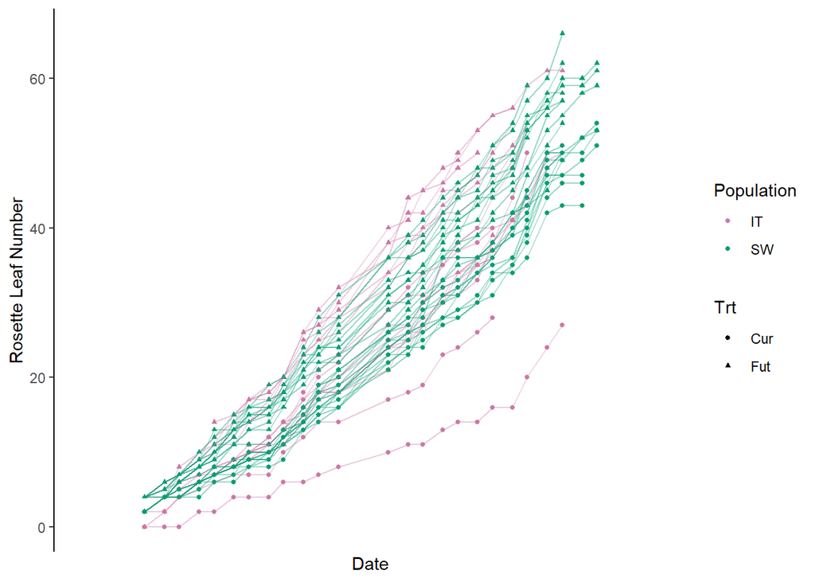

```r
# for plotting purposes, make a grouping column
LeafNumTime$grp <- paste(LeafNumTime$Geno, LeafNumTime$Trt)
RosAreaTime$grp <- paste(RosAreaTime$Geno, RosAreaTime$Trt)
TotalNumTime$grp <- paste(TotalNumTime$Geno, TotalNumTime$Trt)

ggplot(data = LeafNumTime, aes(x = Date2, y = LeafNum)) +
  geom_point(aes(col=Population, shape = Trt), size = 1, show.legend = TRUE) +
  geom_line(aes(group = grp, col = Population), size = 0.4, alpha = 0.4, show.legend = FALSE)+
  labs(y="Rosette Leaf Number",
      x="Date")+
  scale_color_manual(name = "Population",
                     labels = c("IT", "SW"),
                     values = c("#CC79A7", "#009E73"))+
  scale_x_discrete(expand = c(0.2,0))+
  theme_classic()
```

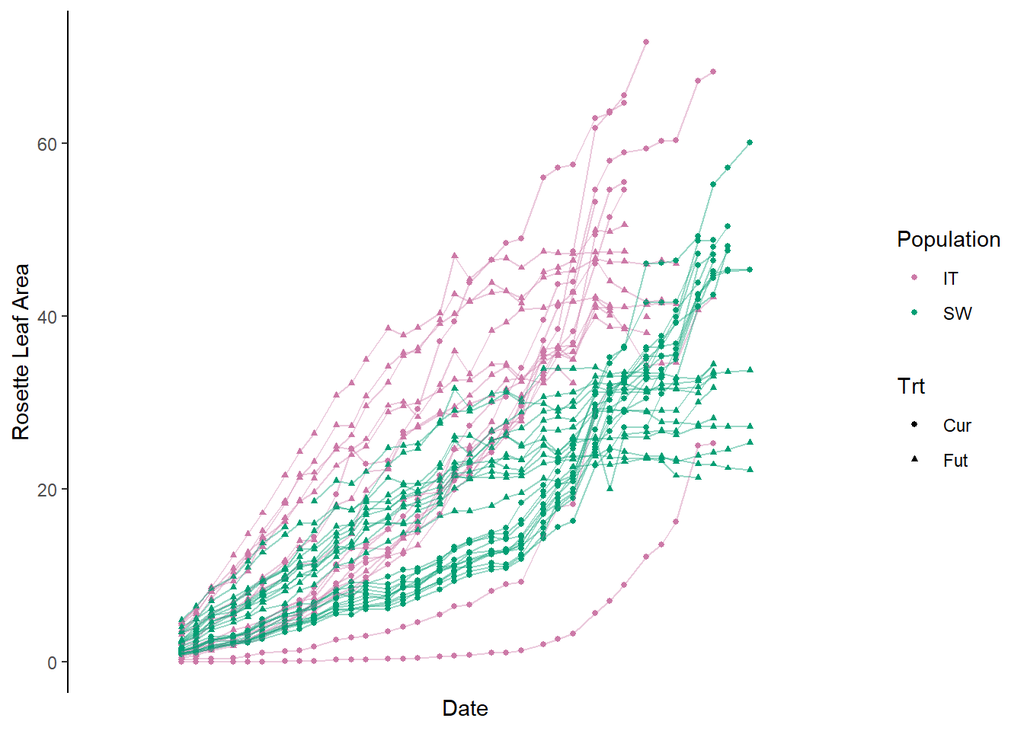

```r
ggplot(data = RosAreaTime, aes(x = Date2, y = LeafArea)) +
  geom_point(aes(col=Population, shape = Trt), size = 1, show.legend = TRUE) +
  geom_line(aes(group = grp, col = Population), size = 0.4, alpha = 0.4, show.legend = FALSE)+
  labs(y="Rosette Leaf Area",
      x="Date")+
  scale_color_manual(name = "Population",
                     labels = c("IT", "SW"),
                     values = c("#CC79A7", "#009E73"))+
  scale_x_discrete(expand = c(0.2,0))+
  theme_classic()
```

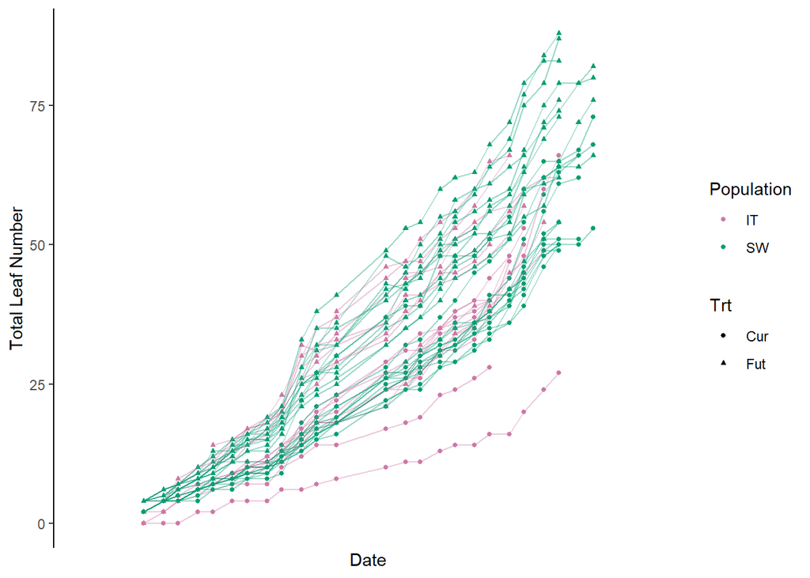

```r
#TotalNum Plot
ggplot(data = TotalNumTime, aes(x = Date2, y = TotalNum)) +
  geom_point(aes(col=Population, shape = Trt), size = 1, show.legend = TRUE) +
  geom_line(aes(group = grp, col = Population), size = 0.4, alpha = 0.4, show.legend = FALSE)+
  labs(y="Total Leaf Number",
      x="Date")+
  scale_color_manual(name = "Population",
                     labels = c("IT", "SW"),
                     values = c("#CC79A7", "#009E73"))+
  scale_x_discrete(expand = c(0.2,0))+
  theme_classic()
```

Area does have some lines that decrease… mistakes? double check them. not able to identify mistakes so all values kept.

How do these plots change by days since emergence? \ We chose to do our analysis in terms of days since emergence since this is more biologically representative of the age of each plant rather than days since planting.

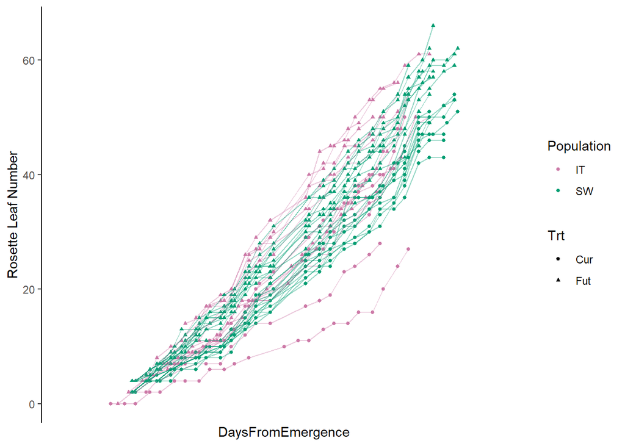

```r
# rosette leaf number
ggplot(data = LeafNumTime, aes(x = DaysFromEmergence, y = LeafNum)) +
  geom_point(aes(col=Population, shape = Trt), size = 1, show.legend = TRUE) +
  geom_line(aes(group = grp, col = Population), size = 0.4, alpha = 0.4, show.legend = FALSE)+
  labs(y="Rosette Leaf Number",
      x="DaysFromEmergence")+
  scale_color_manual(name = "Population",
                     labels = c("IT", "SW"),
                     values = c("#CC79A7", "#009E73"))+
  scale_x_discrete(expand = c(0.2,0))+
  theme_classic()
```

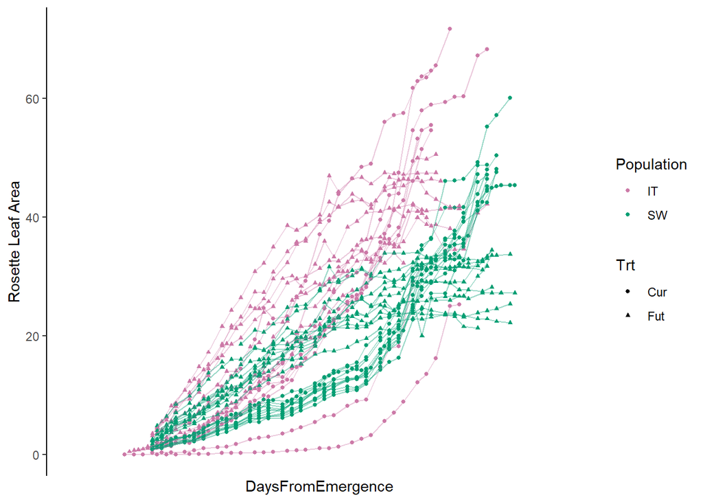

```r
#Rosette area
ggplot(data = RosAreaTime, aes(x = DaysFromEmergence, y = LeafArea)) +
  geom_point(aes(col=Population, shape = Trt), size = 1, show.legend = TRUE) +
  geom_line(aes(group = grp, col = Population), size = 0.4, alpha = 0.4, show.legend = FALSE)+
  labs(y="Rosette Leaf Area",
      x="DaysFromEmergence")+
  scale_color_manual(name = "Population",
                     labels = c("IT", "SW"),
                     values = c("#CC79A7", "#009E73"))+
  scale_x_discrete(expand = c(0.2,0))+
  theme_classic()
```

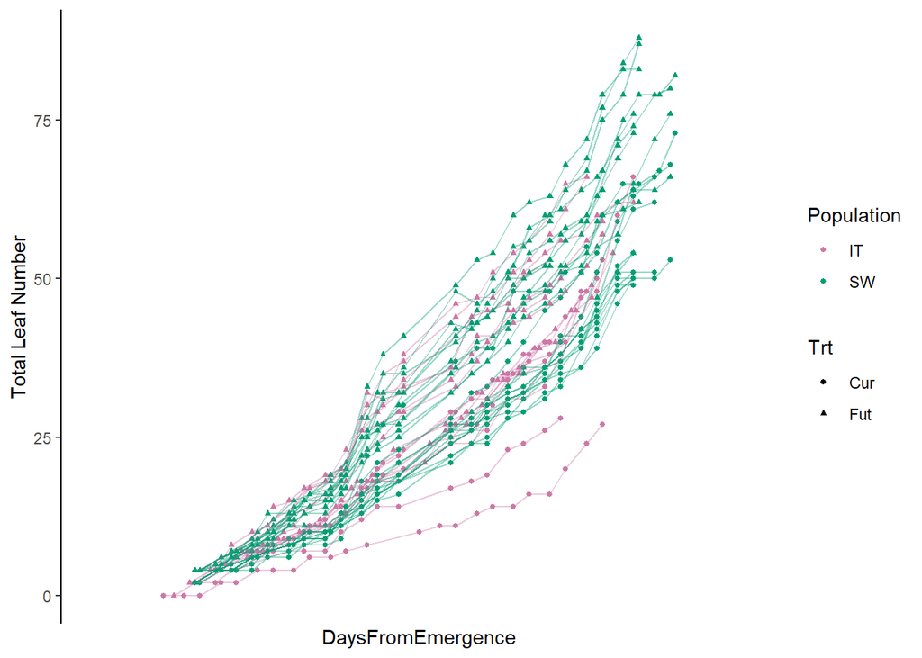

```r
#TotalNum Plot
ggplot(data = TotalNumTime, aes(x = DaysFromEmergence, y = TotalNum)) +
  geom_point(aes(col=Population, shape = Trt), size = 1, show.legend = TRUE) +
  geom_line(aes(group = grp, col = Population), size = 0.4, alpha = 0.4, show.legend = FALSE)+
  labs(y="Total Leaf Number",
      x="DaysFromEmergence")+
  scale_color_manual(name = "Population",
                     labels = c("IT", "SW"),
                     values = c("#CC79A7", "#009E73"))+
  scale_x_discrete(expand = c(0.2,0))+
  theme_classic()
```

## Summarize

Create a summary table that has a mean for each date for each population and treatment

```r
ByDate <- LeafNum %>% group_by(Population, Trt) %>% summarise(across(.col = c(X11.11.2024:X2.10.2025), .fns = list(mean = ~mean(.x, na.rm = TRUE, .group = "keep"))))
#sample size n = ~sum(!is.na(.x))
LeafNumByDate <- pivot_longer(ByDate, cols = !(c(Population, Trt )), names_to = "Date", values_to = "LeafNumMean")

LeafNumByDate$Date<- as.Date(sub("^X","", LeafNumByDate$Date), format = "%m.%d.%Y")

LeafNumByDate$Date2 <- julian(LeafNumByDate$Date, origin = as.Date("2024-11-4"))

#RosArea
RosAreaByDate <- RosArea %>% group_by(Population, Trt) %>% summarise(across(.col = c(X11.25.2024:X2.10.2025), .fns= list(mean = ~mean(.x, na.rm = TRUE, .group = "keep"))))
RosAreaByDate <- pivot_longer(RosAreaByDate, cols = !(c(Population, Trt)), names_to = "Date", values_to = "RosAreaMean")
RosAreaByDate$Date <- as.Date(sub("^X","", RosAreaByDate$Date), format = "%m.%d.%Y")

RosAreaByDate$Date2 <- julian(RosAreaByDate$Date, origin = as.Date("2024-11-4"))

#TotalNum
TotalNumByDate <-TotalNum %>% group_by(Population, Trt) %>% summarise(across(.col = c(X11.11.2024:X2.10.2025), .fns = list(mean = ~mean(.x, na.rm = TRUE, .group = "keep"))))
TotalNumByDate <- pivot_longer(TotalNumByDate, cols = !(c(Population, Trt )), names_to = "Date", values_to = "TotalNumMean")
TotalNumByDate$Date<- as.Date(sub("^X","", TotalNumByDate$Date), format = "%m.%d.%Y")

TotalNumByDate$Date2 <- julian(TotalNumByDate$Date, origin = as.Date("2024-11-4"))
```

Preliminary figures showing changes in mean growth over time - these should give us a good idea of what the final plots may look like from the models. These figures were used for a poster presentation in May 2025.

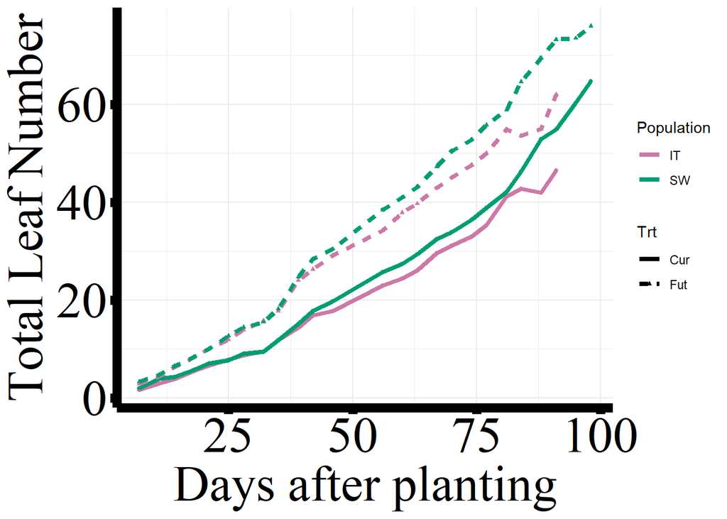

```r
ln_fig <- ggplot(data = LeafNumByDate, aes(x = Date2, y = LeafNumMean)) +
  geom_point(aes(col=Population, shape = Trt), size = 1, show.legend = TRUE) +
  geom_line(aes(group = Trt:Population, col = Population, linetype = Trt), show.legend = TRUE, size = 1.5)+
  labs(y="Rosette Leaf Number",
      x="Days after planting")+
  scale_color_manual(name = "Population",
                     labels = c("IT", "SW"),
                     values = c("#CC79A7", "#009E73"))+
  theme_minimal()+
  theme(
   axis.title = element_text(family = "serif", color = "black", size = 35),
    axis.text = element_text(family = "serif", color = "black", size = 35),
    axis.line = element_line(colour = 'black', linewidth = 3),
    axis.ticks = element_line(color = 'black', linewidth = 3),
    axis.ticks.length=unit(.15, "cm"),
  )

ggsave(ln_fig, filename = "../figures/LeafNumberByDate.png",width = 12.71, height = 7.68, unit = "in",   dpi = 400)
#RosArea
ros_fig <- ggplot(data = RosAreaByDate, aes(x = Date2, y = RosAreaMean)) +
  geom_point(aes(col=Population, shape = Trt), size = 1, show.legend = TRUE) +
  geom_line(aes(group = Trt:Population, col = Population, linetype = Trt), show.legend = TRUE, size = 1.5)+
  labs(y="Rosette Area (cm^2)",
      x="Days after planting")+
  scale_color_manual(name = "Population",
                     labels = c("IT", "SW"),
                     values = c("#CC79A7", "#009E73"))+
  theme_minimal()+
  theme(
   axis.title = element_text(family = "serif", color = "black", size = 35),
    axis.text = element_text(family = "serif", color = "black", size = 35),
    axis.line = element_line(colour = 'black', linewidth = 3),
    axis.ticks = element_line(color = 'black', linewidth = 3),
    axis.ticks.length=unit(.15, "cm"),
  )

ggsave(ros_fig, filename = "../figures/RosetteAreaByDate.png", width = 12.71, height = 7.68, unit = "in", dpi = 400)
#TotalNum
Tn_fig <- ggplot(data = TotalNumByDate, aes(x = Date2, y = TotalNumMean)) +
  geom_point(aes(col=Population, shape = Trt), size = 1, show.legend = TRUE) +
  geom_line(aes(group = Trt:Population, col = Population, linetype = Trt), show.legend = TRUE, size = 1.5)+
  labs(y="Total Leaf Number",
      x="Days after planting")+
  scale_color_manual(name = "Population",
                     labels = c("IT", "SW"),
                     values = c("#CC79A7", "#009E73"))+
  theme_minimal()+
  theme(
   axis.title = element_text(family = "serif", color = "black", size = 35),
    axis.text = element_text(family = "serif", color = "black", size = 35),
    axis.line = element_line(colour = 'black', linewidth = 3),
    axis.ticks = element_line(color = 'black', linewidth = 3),
    axis.ticks.length=unit(.15, "cm"),
  )
ggsave(Tn_fig, filename = "../figures/TotalLeafNumByDate.png", width = 12.71, height = 7.68, unit = "in", dpi = 400)
Tn_fig
```

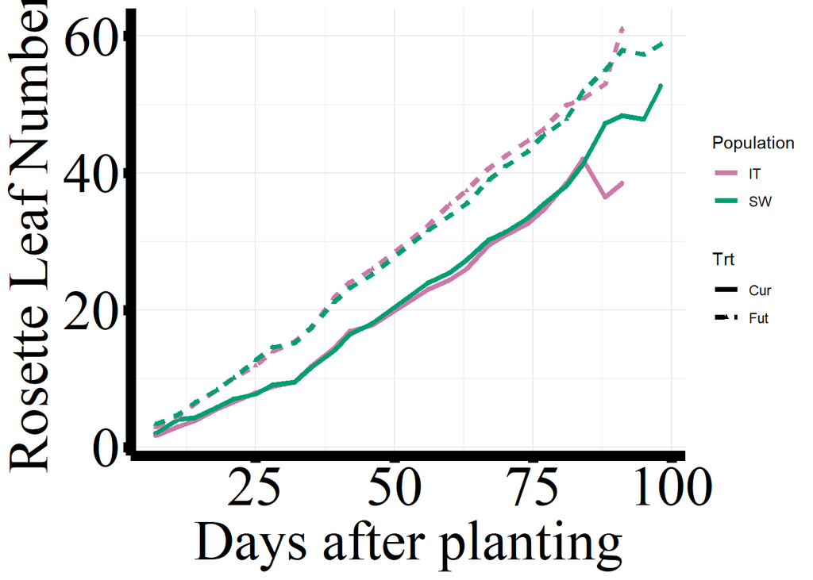

```r
ln_fig
```

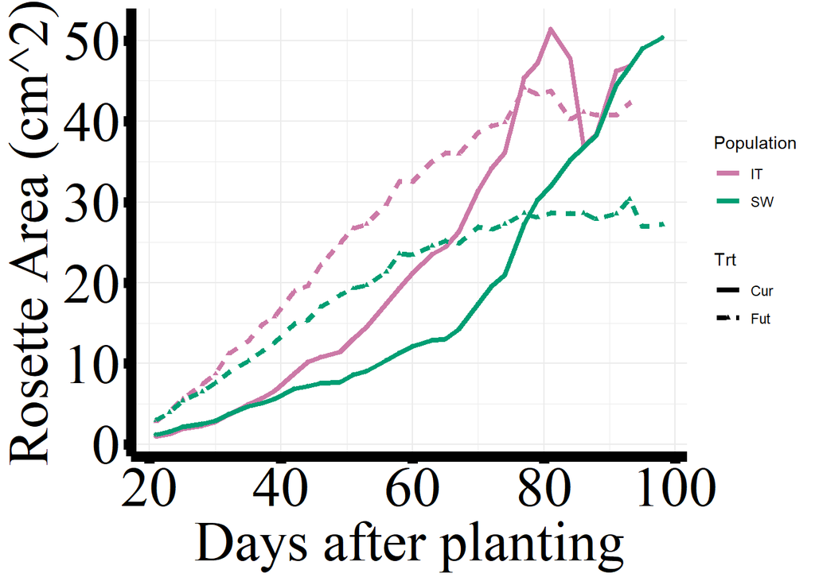

```r
ros_fig
```

Summarize bolting time data by population to support our escape/avoidance results. The statistical analysis for this one trait is also in this section.

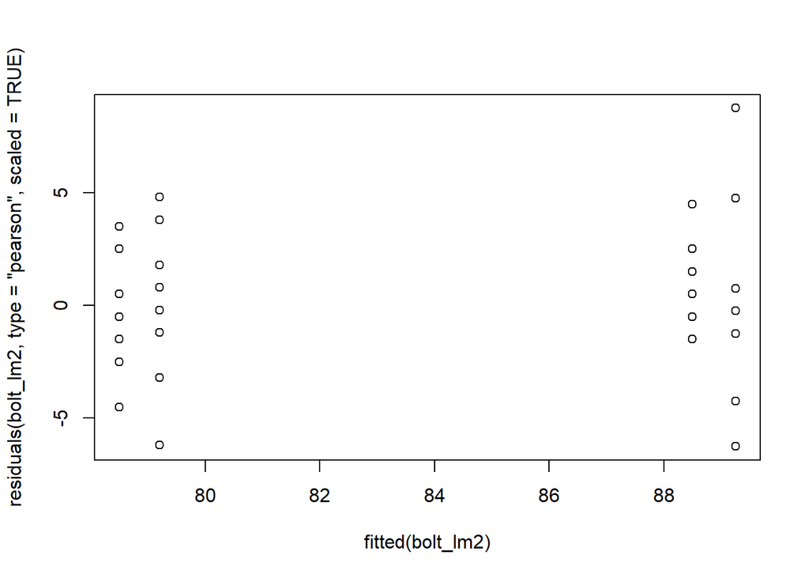

```r
# want time between emergence and bolting as the time to be analyzed
BoltingAnalysis <- Emergence %>%
  select(PotLabel, Treatment, EmergenceDate, BoltingDate) %>%
  mutate(
    Treatment = as.factor(Treatment),
    EmergenceDate = as.Date(EmergenceDate, format = "%m/%d/%Y"),
    BoltingDate = as.Date(BoltingDate, format = "%m/%d/%Y"),
    Genotype = substr(PotLabel, 1, 3)
  )

# keep only plants that emerged and survived to bolting
BoltingAnalysis <- BoltingAnalysis[complete.cases(BoltingAnalysis), ]

# add Population columns
BoltingAnalysis$Population <- "SW"
BoltingAnalysis[BoltingAnalysis$Genotype < 900, "Population"] <- "IT"
BoltingAnalysis$Population <- as.factor(BoltingAnalysis$Population)

# calculate days to bolting
BoltingAnalysis$DaysToBolting <- as.numeric(BoltingAnalysis$BoltingDate - BoltingAnalysis$EmergenceDate)

# model
#bolt_lm <- lmer(DaysToBolting ~ Treatment * Population + (1|Genotype), data = BoltingAnalysis, contrasts = list(Treatment=contr.sum, Population = contr.sum))
#plot(fitted(bolt_lm), residuals(bolt_lm, type = "pearson", scaled = TRUE))
#summary(bolt_lm)

# we don't have replication of genotypes so the previous  model is overfit. removing the random effect does not meaningfully change the results.
bolt_lm2 <- lm(DaysToBolting ~ Treatment * Population, data = BoltingAnalysis, contrasts = list(Treatment=contr.sum, Population = contr.sum))
plot(fitted(bolt_lm2), residuals(bolt_lm2, type = "pearson", scaled = TRUE))
```

```r
summary(bolt_lm2)
```

```
##
## Call:
## lm(formula = DaysToBolting ~ Treatment * Population, data = BoltingAnalysis,
##     contrasts = list(Treatment = contr.sum, Population = contr.sum))
##
## Residuals:
##    Min     1Q Median     3Q    Max
## -6.250 -1.500 -0.250  1.325  8.750
##
## Coefficients:
##                        Estimate Std. Error t value Pr(>|t|)
## (Intercept)             83.8625     0.4741 176.906  < 2e-16 ***
## Treatment1              -0.3625     0.4741  -0.765    0.449
## Population1             -5.0125     0.4741 -10.574 7.08e-13 ***
## Treatment1:Population1   0.0125     0.4741   0.026    0.979
## ---
## Signif. codes:  0 '***' 0.001 '**' 0.01 '*' 0.05 '.' 0.1 ' ' 1
##
## Residual standard error: 3.03 on 38 degrees of freedom
## Multiple R-squared:  0.7472, Adjusted R-squared:  0.7273
## F-statistic: 37.45 on 3 and 38 DF,  p-value: 1.96e-11
```

```r
# run anova for stats
#anova(bolt_lm)
anova(bolt_lm2)
```

```
## Analysis of Variance Table
##
## Response: DaysToBolting
##                      Df  Sum Sq Mean Sq  F value    Pr(>F)
## Treatment             1    0.35    0.35   0.0377    0.8470
## Population            1 1030.92 1030.92 112.2970 6.648e-13 ***
## Treatment:Population  1    0.01    0.01   0.0007    0.9791
## Residuals            38  348.85    9.18
## ---
## Signif. codes:  0 '***' 0.001 '**' 0.01 '*' 0.05 '.' 0.1 ' ' 1
```

```r
# get emmeans
#bolting_means <- as.data.frame(emmeans(bolt_lm, specs = c("Treatment", "Population")))
bolting_means2 <- as.data.frame(emmeans(bolt_lm2, specs = c("Treatment", "Population")))
```

## Statistical Analysis

This section has statistical analysis for each of the three traits. We are doing a two step analysis method where in the first step we fit a model for each genotype of the trait against time to get a growth rate (slope). Then in the second model we fit the growth rate as predicted by population, treatment, and their interaction. One negative about this method is that we lose the uncertainty around the slopes in the first model when we do the second model.

Another way to do this would require lmer to run models with a 3-way interaction. Because we added a quadratic term, these models would require a linear term 3-way interaction and a quadratic term 3-way interaction with genotype nested in treatment as a random effect. Because these were quite complicated with a lot of terms given our sample size, we stuck to the 2-step method.

#### Prep for plots

This section makes plots, so set the theme to be the same for all of them.

```r
theme_set(theme_classic())
theme_update(legend.title = element_text(family = "serif", color = "black", size = 14),
    legend.text = element_text(family = "serif", color = "black", size = 14),
    axis.title = element_text(family = "serif", color = "black", size = 14),
    axis.text = element_text(family = "serif", color = "black", size = 14),
    axis.line = element_line(colour = 'black', linewidth = 1),
    axis.ticks = element_line(color = 'black', linewidth = 1),
    axis.ticks.length=unit(.15, "cm"),
    legend.spacing.y = unit(0.03, "cm"),
    panel.border = element_blank(),
    panel.grid.major.x = element_blank(),
    panel.grid.minor.x = element_blank(),
    plot.margin = margin(t=0.25, r=0.075, b=0.075, l=0.05, unit = "in")
    )
```

### Rosette Area

Format data and take first look at trends

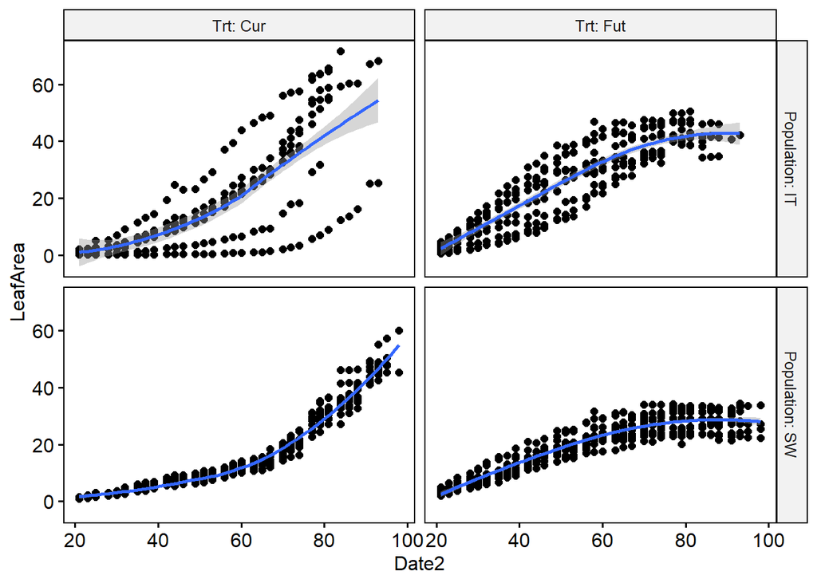

```r
# remove NAs
rosarea <- RosAreaTime[complete.cases(RosAreaTime), ]

# make geno a factor
rosarea$Geno <- as.factor(rosarea$Geno)

# add log transformed column
rosarea$log_area <- log(rosarea$LeafArea)

# plot trends by grouping with loess fit lines
# check ancova assumptions
ggscatter(
  rosarea, x = "Date2", y = "LeafArea",
  facet.by  = c("Population", "Trt"),
  short.panel.labs = FALSE
  )+
  stat_smooth(method = "loess", span = 0.9)
```

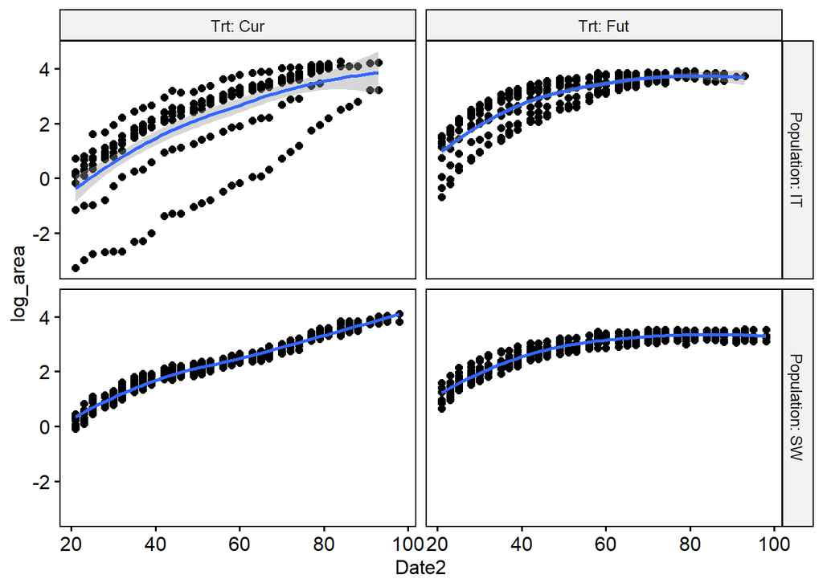

```r
ggscatter(
  rosarea, x = "Date2", y = "log_area",
  facet.by  = c("Population", "Trt"),
  short.panel.labs = FALSE
  )+
  stat_smooth(method = "loess", span = 0.9)
```

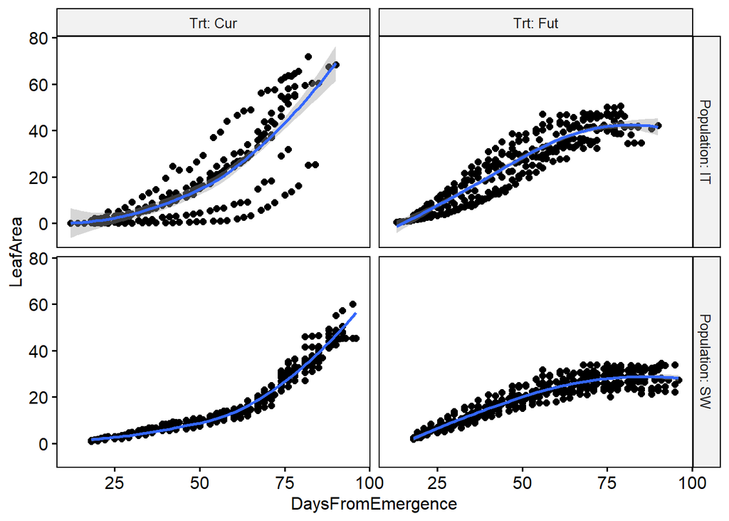

```r
# change to days since Emergence
ggscatter(
  rosarea, x = "DaysFromEmergence", y = "LeafArea",
  facet.by  = c("Population", "Trt"),
  short.panel.labs = FALSE
  )+
  stat_smooth(method = "loess", span = 0.9)
```

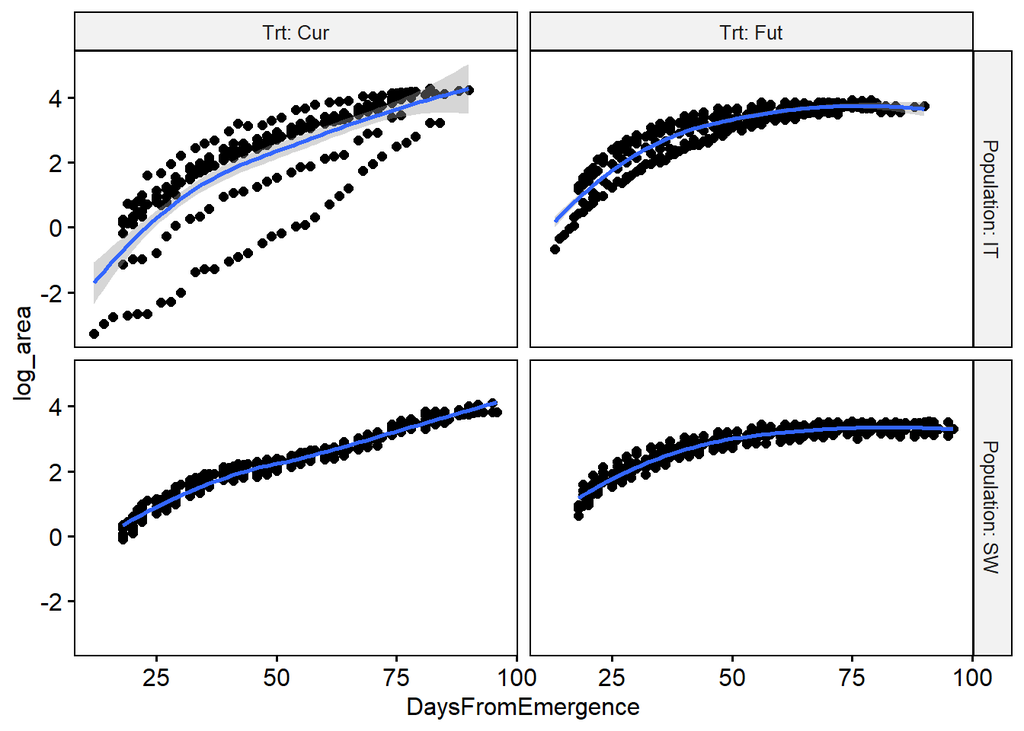

```r
ggscatter(
  rosarea, x = "DaysFromEmergence", y = "log_area",
  facet.by  = c("Population", "Trt"),
  short.panel.labs = FALSE
  )+
  stat_smooth(method = "loess", span = 0.9)
```

Run models to get growth rate (slopes). Quadratic was added for a better fit, so also need to get gammas.

```r
# add quadratic term, no scaling
rosarea$quad_date <- rosarea$DaysFromEmergence^2

#add quadratic term - this version is centered to reduce colinearity with the linear term
#rosarea$quad_date <- scale((rosarea$Date2)^2, scale = FALSE)
# scaling doesn't change the results, so did not scale to not worry about interpreting scaled date values
```

```r
# make a list of dataframes where each dataframe is the leaf areas for one genotype
area_by_geno <- list(rep(NA, times = 44))
genos <- unique(rosarea$Geno)
trts <- unique(rosarea$Trt)

# current
for (i in 1:22){
  area_by_geno[[i]] <- rosarea[(rosarea$Geno == genos[i]& rosarea$Trt == trts[1]), ]
}
# 102 and 105 have no data

#do a second loop for fut so notating for area list is easier
for (i in 1:length(genos)){
  area_by_geno[[22+i]] <- rosarea[(rosarea$Geno == genos[i]& rosarea$Trt == trts[2]), ]
}

area_by_geno <- area_by_geno[c(1,3,4,6:44)]
```

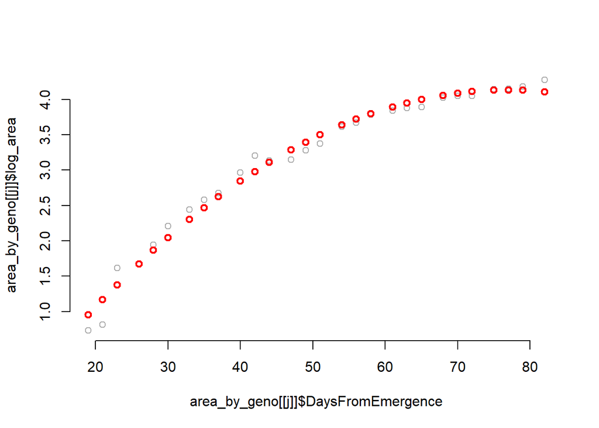

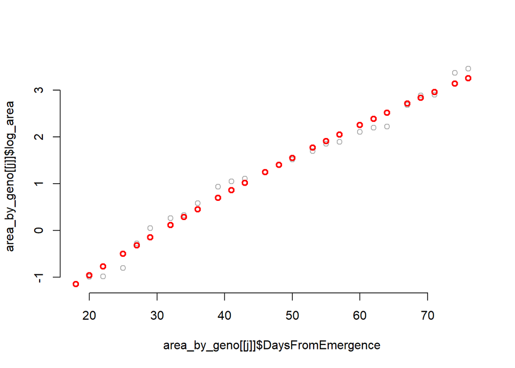

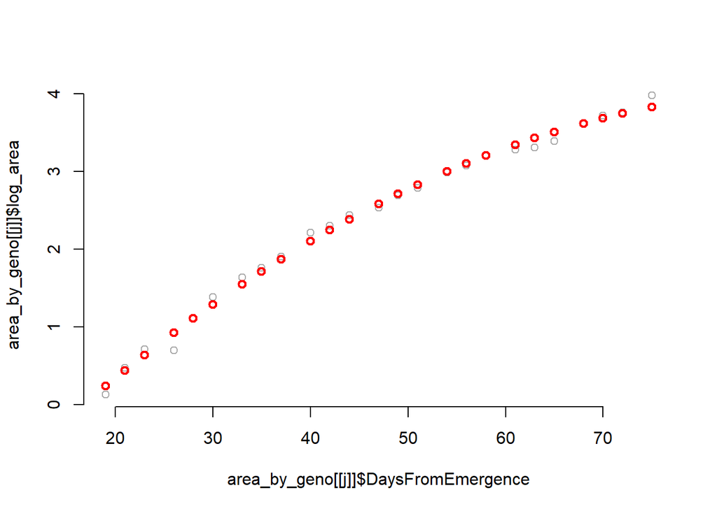

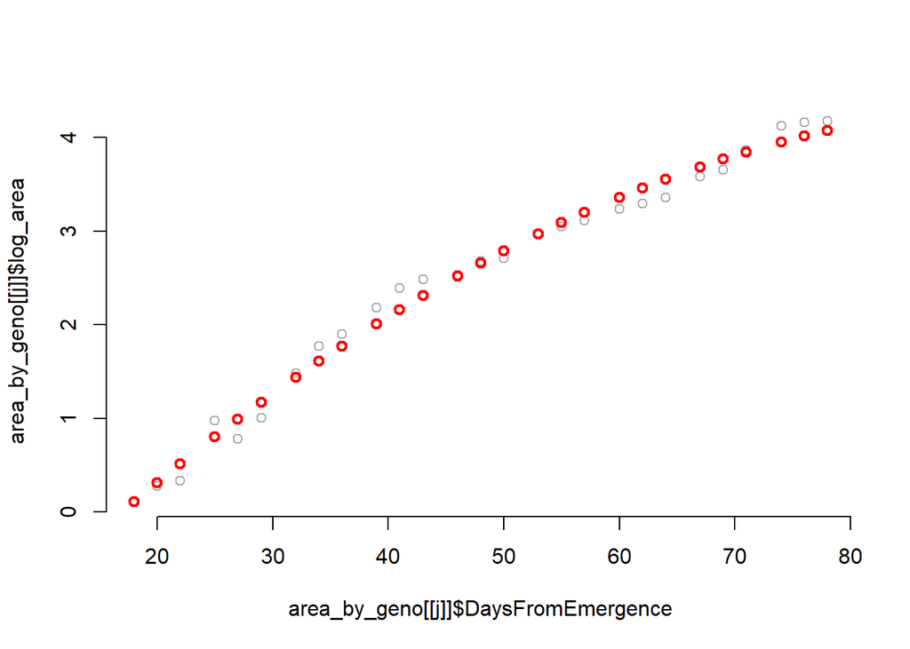

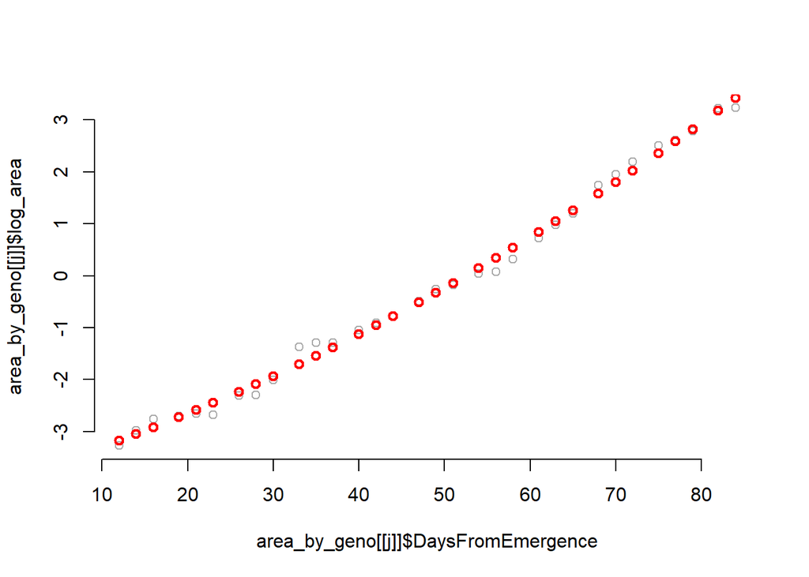

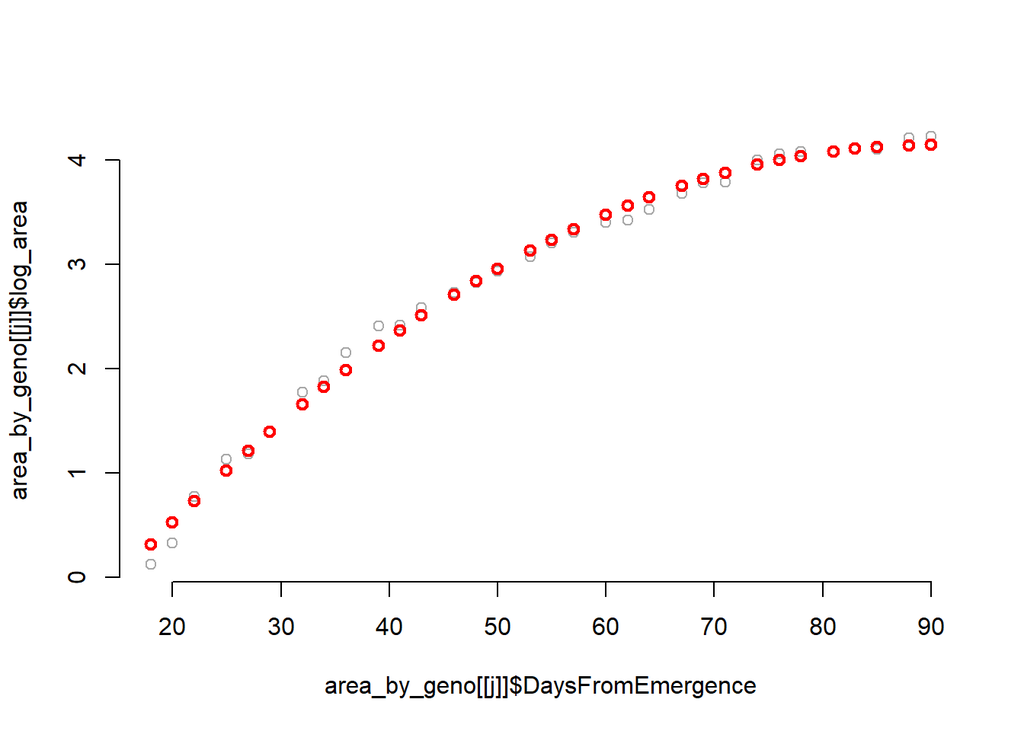

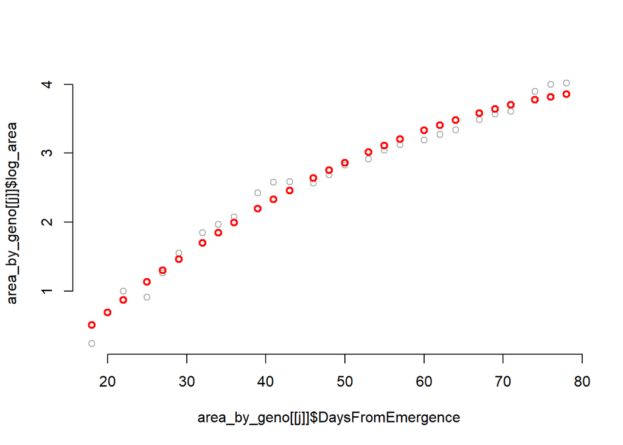

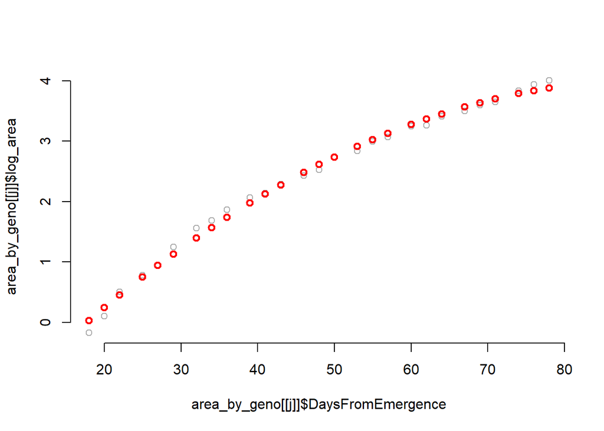

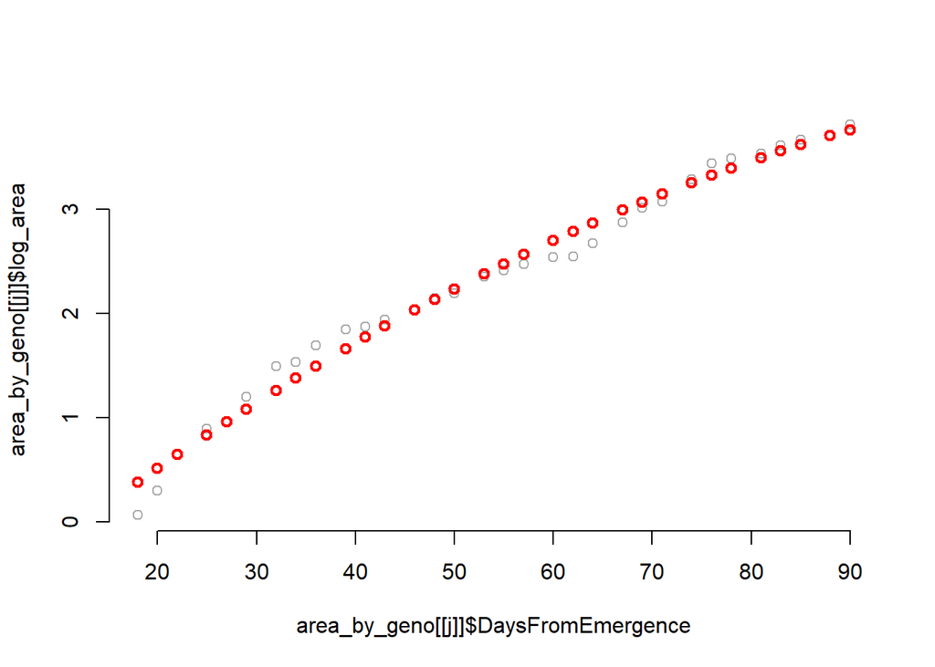

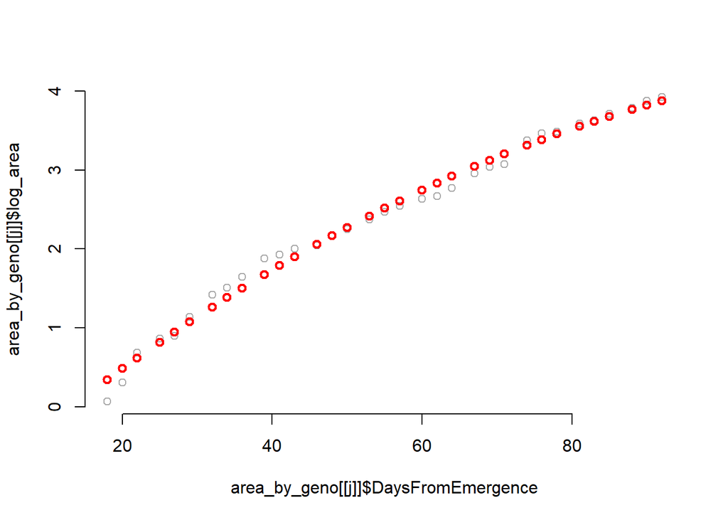

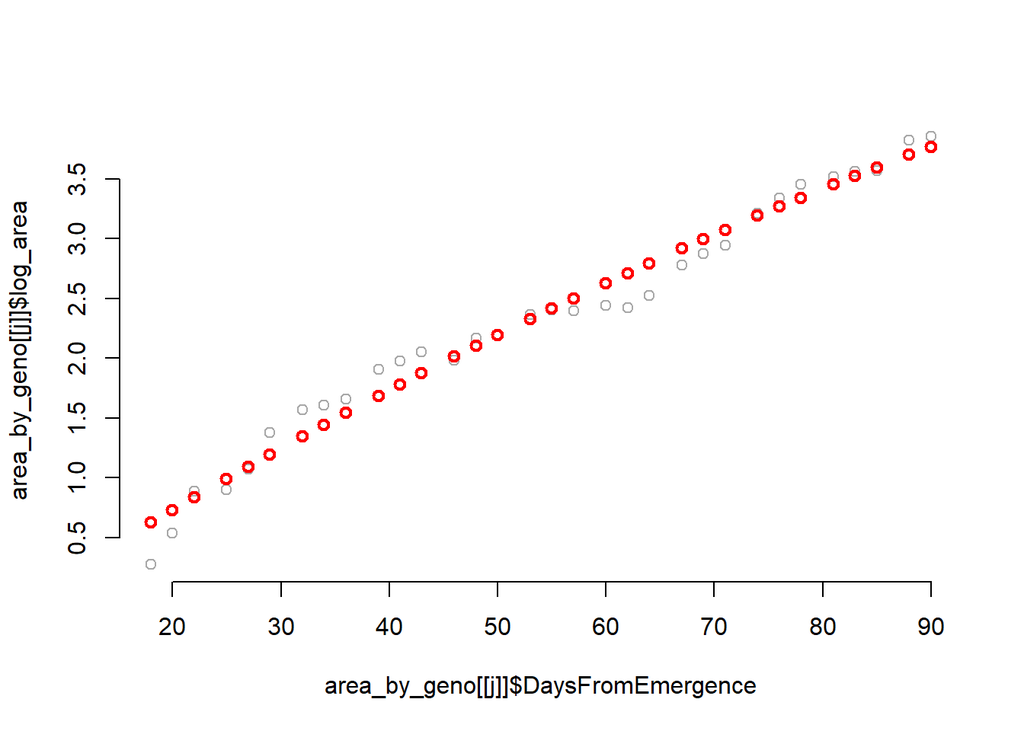

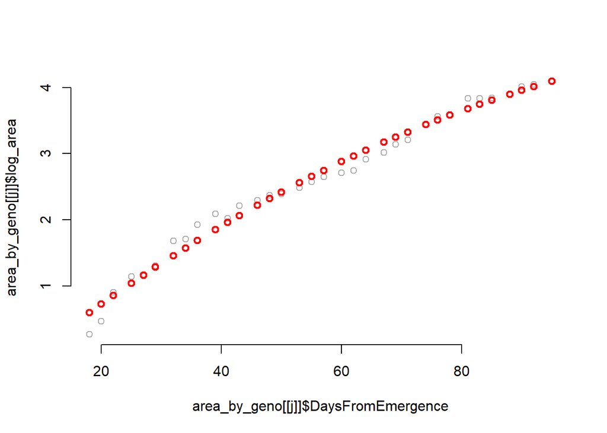

[30 more figures not shown]

```r
# run a model for each item in the area_by_geno list
# df to save slopes
slopes <- data.frame(Geno = c(genos[c(1,3,4,6:22)], genos),
                     Trt = as.factor(c(rep("Cur", times = 20), rep("Fut", times = 22))),
                     Beta = rep(NA, times = 42))
slopes$uniqueID <- paste0(slopes$Trt, slopes$Geno )
slopes$Pop <- factor("SW", levels = c("SW", "IT"))
slopes[as.numeric(slopes$Geno) < 11, "Pop" ] <- "IT"

for (j in 1:length(area_by_geno)){
  tmp <- lm(log_area ~ DaysFromEmergence, data = area_by_geno[[j]])
  # do any of the models fit well? commented out but decent
  #hist(residuals(tmp))
  #plot(fitted(tmp), residuals(tmp, type = "pearson", scaled = TRUE))
  slopes$Beta[j] <- tmp[["coefficients"]][["DaysFromEmergence"]]
  # model data
  #modData = tmp$coefficients[1]+area_by_geno[[j]]$DaysFromEmergence*tmp$coefficients[2]
  ## look at the model-predicted data curve on top of the actual data
  #plot(area_by_geno[[j]]$DaysFromEmergence, area_by_geno[[j]]$log_area, bty="n", col="darkgray")
  #points(area_by_geno[[j]]$DaysFromEmergence, modData,col="red",lwd=2)

}

# add quad to initial model
slopes2 <- data.frame(Geno = c(genos[c(1,3,4,6:22)], genos),
                     Trt = as.factor(c(rep("Cur", times = 20), rep("Fut", times = 22))),
                     Beta = rep(NA, times = 42),
                     gamma = rep(NA, times = 42))
slopes2$uniqueID <- paste0(slopes$Trt, slopes$Geno )
slopes2$Pop <- factor("SW", levels = c("SW", "IT"))
slopes2[as.numeric(slopes2$Geno) < 11, "Pop" ] <- "IT"

for (j in 1:length(area_by_geno)){
  tmp <- lm(log_area ~ DaysFromEmergence + quad_date, data = area_by_geno[[j]])
  # do any of the models fit well? commented plots our but yes
  #hist(residuals(tmp))
  #plot(fitted(tmp), residuals(tmp, type = "pearson", scaled = TRUE))
  slopes2$Beta[j] <- tmp[["coefficients"]][["DaysFromEmergence"]]
  slopes2$gamma[j] <- tmp[["coefficients"]][["quad_date"]]
  slopes2$intercept[j] <- tmp[["coefficients"]][["(Intercept)"]]
  # model data
  #
  modData = tmp$coefficients[1]+as.numeric(area_by_geno[[j]]$DaysFromEmergence)*tmp$coefficients[2] + as.numeric(area_by_geno[[j]]$quad_date)*tmp$coefficients[3]
  ## look at the model-predicted data curve on top of the actual data
  plot(area_by_geno[[j]]$DaysFromEmergence, area_by_geno[[j]]$log_area, bty="n", col="darkgray")
  points(area_by_geno[[j]]$DaysFromEmergence, modData,col="red",lwd=2)

}
```